# Chapter 1: Data Visualisation with ggplot2

## Geometric objects

Thinking a little more about the grammar of graphics, more genereally, **geoms** are the geometrical object that a plot uses to represent data. The type of geom we use depends on what kind of data we are trying to visualise and exactly what we are trying to express.

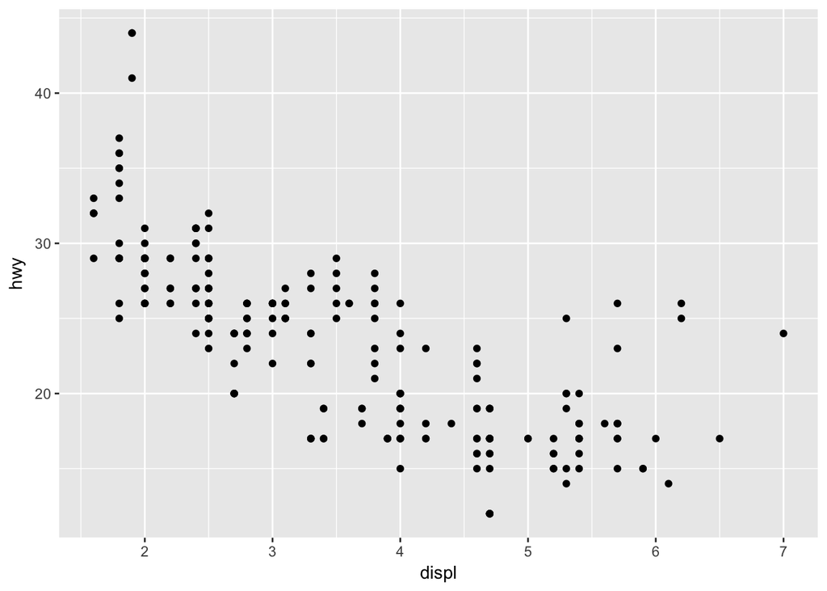

```r
ggplot(data = mpg) +
  geom_point(mapping = aes(x = displ, y = hwy))
```

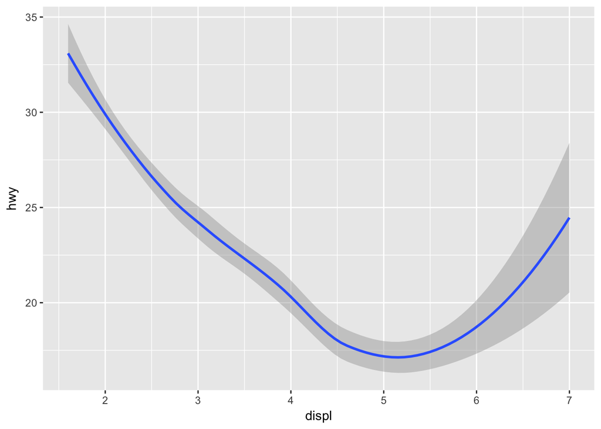

```r
ggplot(data = mpg) +
  geom_smooth(mapping = aes(x = displ, y = hwy))
```

Using the **geom_smooth** option, fits a polynomial surface determined by one or more numerical predictors, using local fitting.

It is also possible to plot the same smoothed function for each category of a variable:

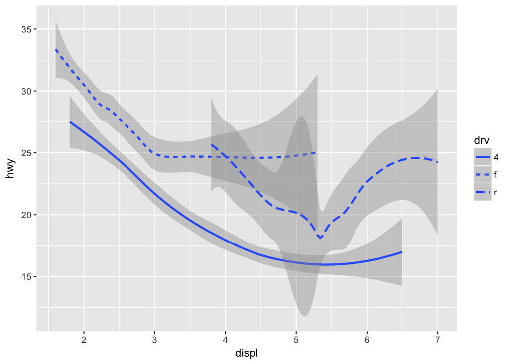

```r
ggplot(data = mpg) +
  geom_smooth(mapping = aes(x = displ, y = hwy, linetype = drv))
```

The variable *drv* expresses the drivetrain of the car, that is front-wheel, four-wheel or real-wheel drive.

Notice, that if the option for the displayed legend for *drv* is false and we add an option for colour within aesthetic, the lines then become differentiated by colour:

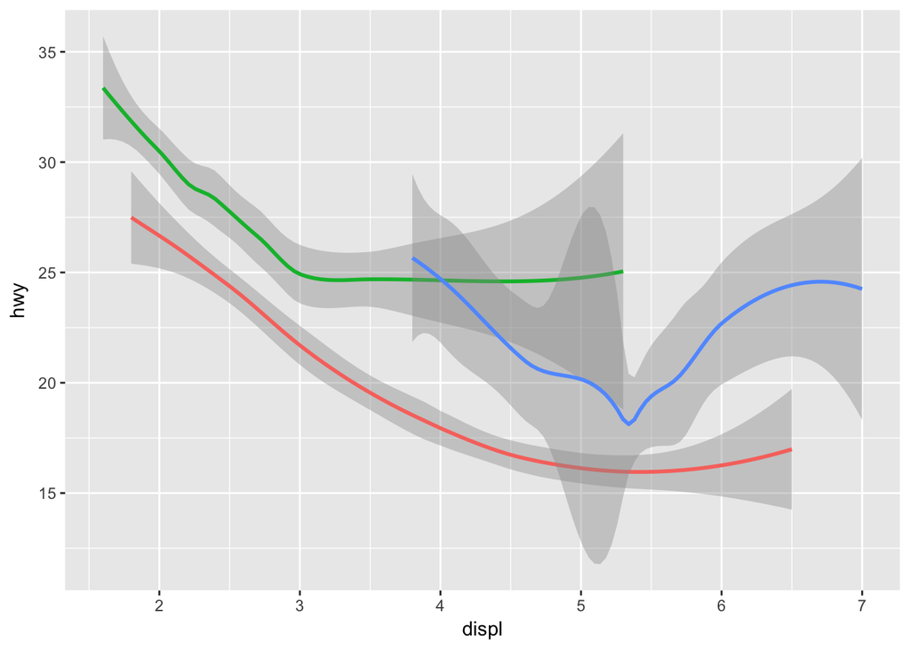

```r
ggplot(data = mpg) +
  geom_smooth(
    mapping = aes(x = displ, y = hwy, colour = drv),
  show.legend = FALSE
  )
```

Implicit in the above seems to be some dilemma about haveing to pick just one plot type but this isn’t the case. We are easily able to overlay graphics and plot types:

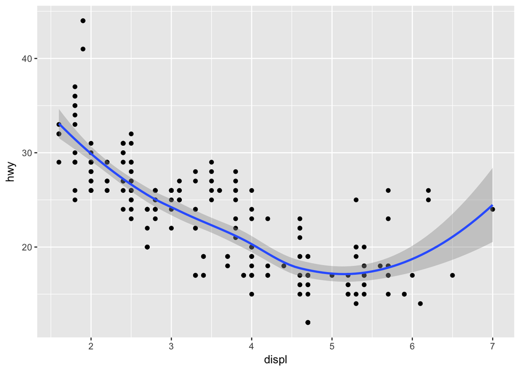

```r
ggplot(data = mpg) +
  geom_point(mapping = aes(x = displ, y=hwy)) +
  geom_smooth(mapping = aes(x = displ, y=hwy))
```

Here, we have the graph using the point geom and we have overlayed a graph using the polynomial smooth.

The above syntax can be repetitive and as such, we can state the mappings and aesthetics as arguments in the ggplot function and leave the arguments for both point and smooth geoms as empty:

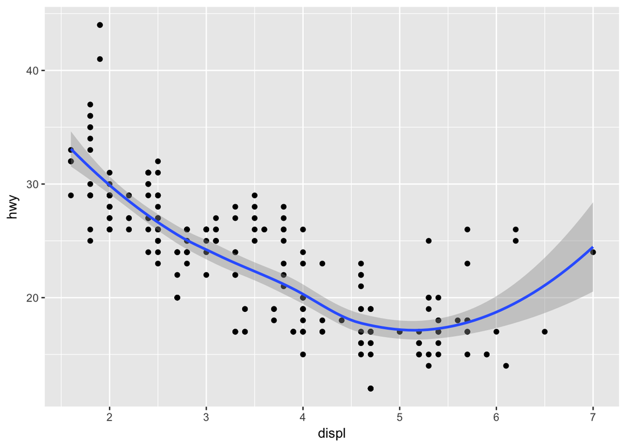

```r
ggplot(data = mpg, mapping = aes(x=displ, y=hwy)) +
  geom_point() +
  geom_smooth()
```

In addition, we can specify that only one layer of the graphic be categorised by a variable, for example, perhaps we just want to augment the point layer by class:

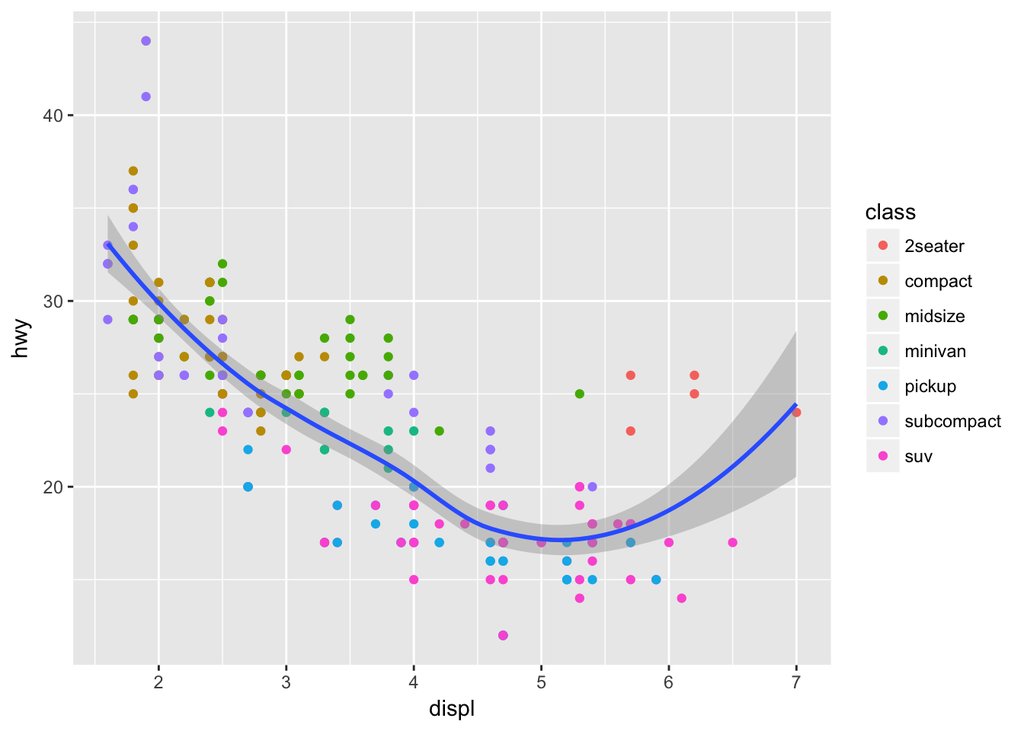

```r
ggplot(data = mpg, mapping = aes(x = displ, y =hwy)) +
  geom_point(mapping = aes(colour = class)) +
  geom_smooth()
```